# assingment 2

```python
import seaborn as sns
import matplotlib.pyplot as plt
```

```python
df = sns.load_dataset("car_crashes")
df.head()
```

|  | total | speeding | alcohol | not_distracted | no_previous | ins_premium | ins_losses | abbrev |
| --- | --- | --- | --- | --- | --- | --- | --- | --- |
| 0 | 18.8 | 7.332 | 5.640 | 18.048 | 15.040 | 784.55 | 145.08 | AL |
| 1 | 18.1 | 7.421 | 4.525 | 16.290 | 17.014 | 1053.48 | 133.93 | AK |
| 2 | 18.6 | 6.510 | 5.208 | 15.624 | 17.856 | 899.47 | 110.35 | AZ |
| 3 | 22.4 | 4.032 | 5.824 | 21.056 | 21.280 | 827.34 | 142.39 | AR |
| 4 | 12.0 | 4.200 | 3.360 | 10.920 | 10.680 | 878.41 | 165.63 | CA |

1. Scatterplot (Alcohol vs. Total Crashes)

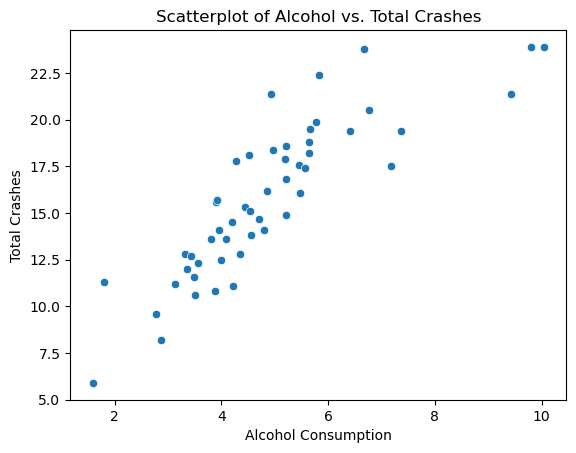

```python
sns.scatterplot(data=df, x="alcohol", y="total")
plt.title("Scatterplot of Alcohol vs. Total Crashes")
plt.xlabel("Alcohol Consumption")
plt.ylabel("Total Crashes")
plt.show()
```

INFERENCE: There is a positive correlation between alcohol consumption and the total number of crashes meaning that higher the alcohol consumption, the increased amount of car crashes

1. Boxplot (Insurance Premiums)

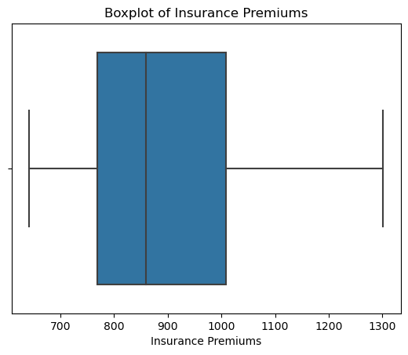

```python
sns.boxplot(data=df, x="ins_premium")
plt.title("Boxplot of Insurance Premiums")
plt.xlabel("Insurance Premiums")
plt.show()
```

1. Histogram (Total Crashes)

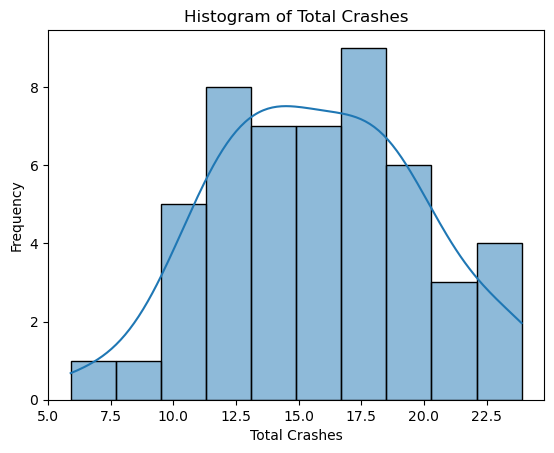

```python
sns.histplot(data=df, x="total", bins=10, kde=True)
plt.title("Histogram of Total Crashes")
plt.xlabel("Total Crashes")
plt.ylabel("Frequency")
plt.show()
```

INFERENCE: The distribution of total crashes is in a symmetrical distribution meaning that there is an normal distribution of crashes

1. Barplot (Number of Speeding Fatalities by State)

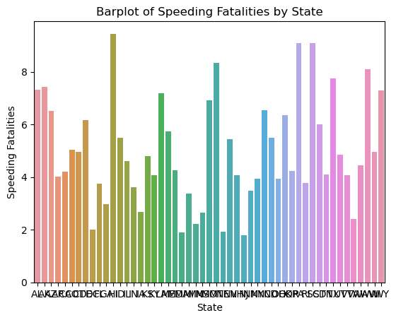

```python
sns.barplot(data=df, x="abbrev", y="speeding")
plt.title("Barplot of Speeding Fatalities by State")
plt.xlabel("State")
plt.ylabel("Speeding Fatalities")
plt.show()
```

INFERENCE: The barplot displays the number of speeding fatalities for each states so that we can identify states with higher or lower speeding-related fatalities.

1. Heatmap (Correlation Matrix)

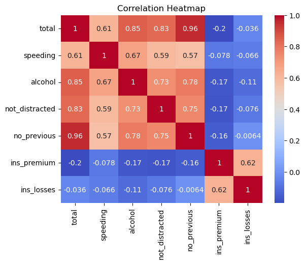

```python
correlation_matrix = df.corr()
sns.heatmap(correlation_matrix, annot=True, cmap="coolwarm")
plt.title("Correlation Heatmap")
plt.show()
```

INFERENCE: The heatmap displays the correlation between numerical variables in the dataset. Total crashes with alcohol has strong positive correlation and with ins_premium has the strongest negetive correlation

1. Regression Plot (Total Crashes vs Alcohol)

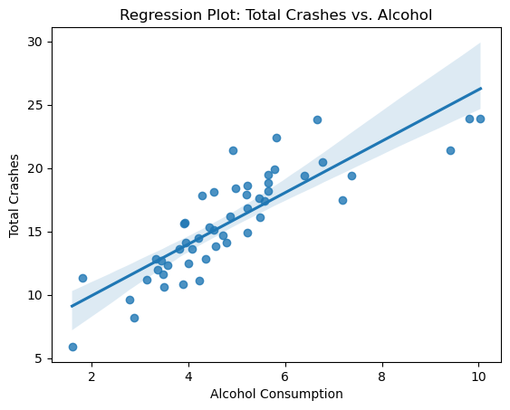

```python
sns.regplot(data=df, x="alcohol", y="total")
plt.title("Regression Plot: Total Crashes vs. Alcohol")
plt.xlabel("Alcohol Consumption")
plt.ylabel("Total Crashes")
plt.show()
```

INFERENCE: The regression plot indicates a positive linear relationship between alcohol consumption and total crashes.

1. Line plot (Total Crashes by State)

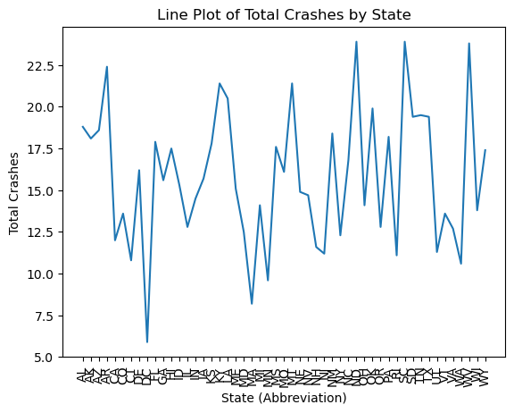

```python
import matplotlib.pyplot as plt

sns.lineplot(data=df, x='abbrev', y='total')
plt.title("Line Plot of Total Crashes by State")
plt.xlabel("State (Abbreviation)")
plt.ylabel("Total Crashes")
plt.xticks(rotation=90)
plt.show()
```

INFERENCE: The line plot shows a visual representation of how the total number of crashes varies across states. States with higher values on the y-axis have experienced more total crashes, while states with lower values have fewer crashes.

1. Violinplot (Alcohol by State)

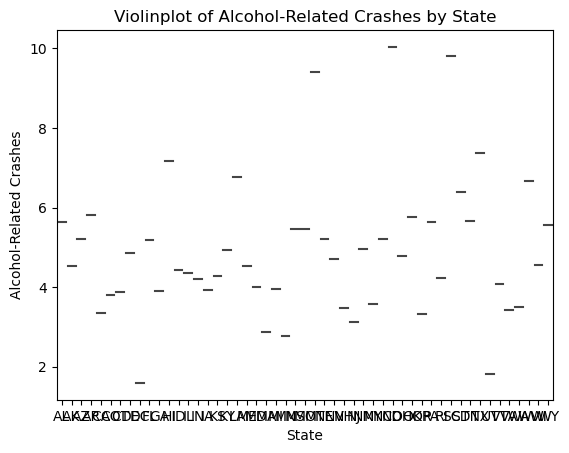

```python
sns.violinplot(data=df, x="abbrev", y="alcohol")
plt.title("Violinplot of Alcohol-Related Crashes by State")
plt.xlabel("State")
plt.ylabel("Alcohol-Related Crashes")
plt.show()
```

INFERENCE: The violinplot visualizes the distribution of alcohol-related crashes by state, displaying only the peaks.

1. Pairplot

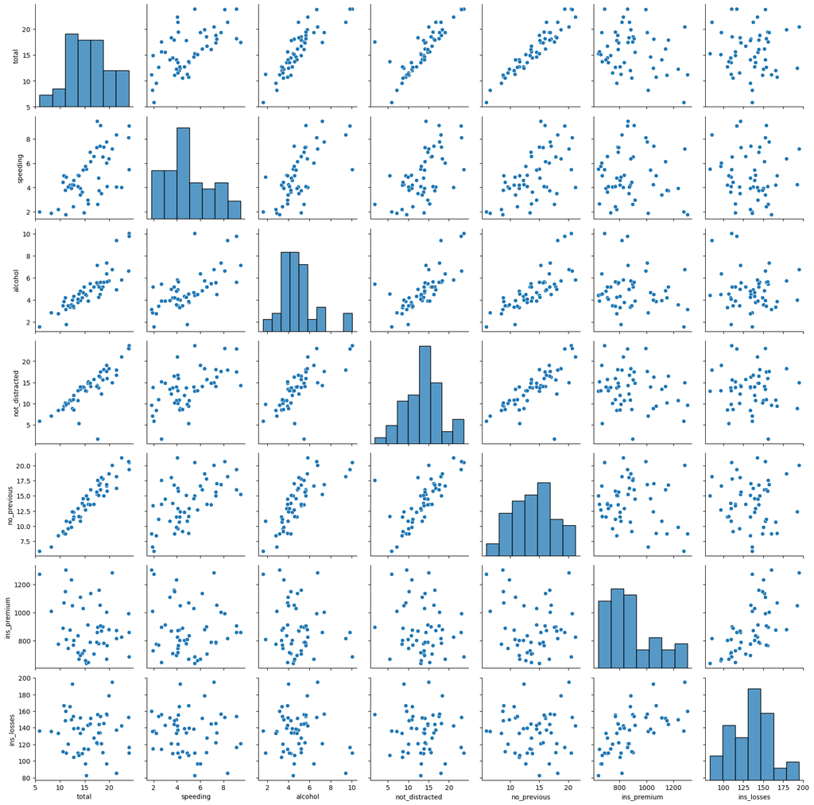

[figure not shown]

```python
sns.pairplot(df)
plt.title("Pairplot of Car Crashes Data")
plt.show()
```

INFERENCE: The pairplot shows relationships between numerical variables. We can observe some positive correlations between variables 'total', 'speeding', and 'alcohol'.

1. Countplot (Number of Speeding Fatalities by State)

[figure not shown]

```python
sns.countplot(data=df, x="abbrev", hue="speeding")
plt.title("Countplot of Speeding Fatalities by State")
plt.xlabel("State")
plt.ylabel("Count")
plt.legend(title="Speeding")
plt.show()
```